# 20210506_mlr

Guillermina Senn

5/6/2021

Este script es para explorar los datos (respuestas y covariables) a escala de las unidades homogeneas. 1. Replicar lo que hace Mariano Cordoba en clase. 2. Ejercitar distintas librerias de graficos.

## 0. Librerias y funciones

```
## To access larger datasets in this package, install the spDataLarge
## package with: `install.packages('spDataLarge',
## repos='https://nowosad.github.io/drat/', type='source')`
```

[output not shown]

Funciones:

```r
corr_simple <- function(data = df, sig = 0.5){
  #convert data to numeric in order to run correlations
  #convert to factor first to keep the integrity of the data - each value will become a number rather than turn into NA
  df_cor <- data %>% mutate_if(is.character, as.factor)
  df_cor <- df_cor %>% mutate_if(is.factor, as.numeric)
  #run a correlation and drop the insignificant ones
  corr <- cor(df_cor)
  #prepare to drop duplicates and correlations of 1
  corr[lower.tri(corr, diag=TRUE)] <- NA
  #drop perfect correlations
  corr[corr == 1] <- NA
  #turn into a 3-column table
  corr <- as.data.frame(as.table(corr))
  #remove the NA values from above
  corr <- na.omit(corr)
  #select significant values
  corr <- subset(corr, abs(Freq) > sig)
  #sort by highest correlation
  corr <- corr[order(-abs(corr$Freq)),]
  return(corr)
}
```

## 1. Cargar los datos

```r
path <- '../data/raw/descriptUnidadAnalisis/'
```

Voy a unir las variables.

1. Comienzo por las edaficas. Parece que todos los `.gpkg` tienen las mismas columnas.

Ahora cargo el resto de los archivos en `descriptUnidadAnalisis`:

## 2. Analisis exploratorio

### 2.4 Correlacion

```r
length(names(data))
```

```
## [1] 187
```

```r
names(data)[order(names(data))]
```

```
##   [1] "Actividades.anuales..doble.ciclo._Porc"
##   [2] "Actividades.estivales_Porc"
##   [3] "Actividades.invernales_Porc"
##   [4] "altitudeMode"
##   [5] "Arbustales.y.matorrales_Porc"
##   [6] "begin"
##   [7] "count"
##   [8] "Cuerpos.de.agua_Porc"
##   [9] "Cultivos.anuales.irrigados_Porc"
##  [10] "Cursos.de.agua_Porc"
##  [11] "CV_ARCILLA"
##  [12] "CV_ARENA"
##  [13] "CV_CC"
##  [14] "CV_CE"
##  [15] "CV_CEextsat"
```

[output cut: 172 more lines]

Una vez que cuente con todas las variables unidas, podria examinar la correlacion lineal ente ellas.

```r
df <- as.data.frame(data[, 15:ncol(data)])
```

```r
cols_mediana <- names(df)[grepl('Mediana_', names(df))]
cols_min <- names(df)[grepl('Minimo_', names(df))]
cols_max <- names(df)[grepl('Maximo_', names(df))]
cols_delete <- c(cols_mediana, cols_min, cols_max)
cols_delete
```

```
##  [1] "Mediana_ARCILLA"    "Mediana_ARENA"      "Mediana_CC"
##  [4] "Mediana_CE"         "Mediana_CEextsat"   "Mediana_CIC"
##  [7] "Mediana_CO"         "Mediana_Cu"         "Mediana_Fe"
## [10] "Mediana_K"          "Mediana_LIMO"       "Mediana_Mg"
## [13] "Mediana_Mn"         "Mediana_Na"         "Mediana_Nt"
## [16] "Mediana_P"          "Mediana_pH"         "Mediana_Zn"
## [19] "Mediana_DEM"        "Mediana_ESPI.LTT"   "Mediana_ESPI.Mean"
## [22] "Mediana_LPD"        "Mediana_MO"         "Mediana_NDVI.LTT"
## [25] "Mediana_NDVI.Mean"  "Mediana_PEND"       "Mediana_Recurrecia"
## [28] "Mediana_VUT"        "Minimo_ARCILLA"     "Minimo_ARENA"
## [31] "Minimo_CC"          "Minimo_CE"          "Minimo_CEextsat"
## [34] "Minimo_CIC"         "Minimo_CO"          "Minimo_Cu"
## [37] "Minimo_Fe"          "Minimo_K"           "Minimo_LIMO"
## [40] "Minimo_Mg"          "Minimo_Mn"          "Minimo_Na"
## [43] "Minimo_Nt"          "Minimo_P"           "Minimo_pH"
## [46] "Minimo_Zn"          "Minimo_DEM"         "Minimo_ESPI.LTT"
## [49] "Minimo_ESPI.Mean"   "Minimo_LPD"         "Minimo_MO"
## [52] "Minimo_NDVI.LTT"    "Minimo_NDVI.Mean"   "Minimo_PEND"
## [55] "Minimo_Recurrecia"  "Minimo_VUT"         "Maximo_ARCILLA"
## [58] "Maximo_ARENA"       "Maximo_CC"          "Maximo_CE"
## [61] "Maximo_CEextsat"    "Maximo_CIC"         "Maximo_CO"
## [64] "Maximo_Cu"          "Maximo_Fe"          "Maximo_K"
## [67] "Maximo_LIMO"        "Maximo_Mg"          "Maximo_Mn"
## [70] "Maximo_Na"          "Maximo_Nt"          "Maximo_P"
## [73] "Maximo_pH"          "Maximo_Zn"          "Maximo_DEM"
## [76] "Maximo_ESPI.LTT"    "Maximo_ESPI.Mean"   "Maximo_LPD"
## [79] "Maximo_MO"          "Maximo_NDVI.LTT"    "Maximo_NDVI.Mean"
## [82] "Maximo_PEND"        "Maximo_Recurrecia"  "Maximo_VUT"
```

```r
df1 <- df %>%
  select(-cols_delete)
```

```
## Note: Using an external vector in selections is ambiguous.
## i Use `all_of(cols_delete)` instead of `cols_delete` to silence this message.
## i See <https://tidyselect.r-lib.org/reference/faq-external-vector.html>.
```

```r
corr <- corr_simple(data = df1)
head(corr, 2)
```

```
##             Var1        Var2      Freq
## 1870    id_unico        zone 1.0000000
## 7193 CV_ESPI.LTT CV_NDVI.LTT 0.9256728
```

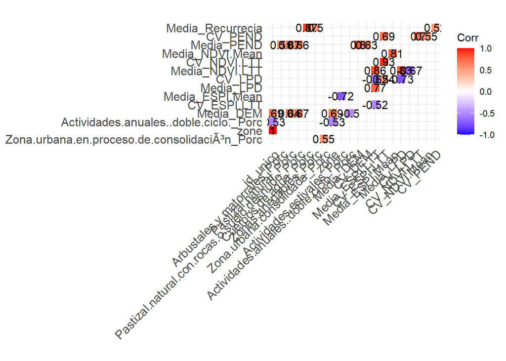

```r
mtx_corr <- reshape2::acast(corr, Var1~Var2, value.var="Freq")
ggcorrplot(mtx_corr, outline.col = 'white', lab = TRUE, insig = 'blank')
```

#### Analisis de correlaciones lineales para las variables respuesta:

**LPD**: Es similar al ESPI y esta basado en NDVI.

- La media LPD tiene correlacion 0.77 con la media de ESPI LTT, y 0.83 con la media NDVI.LTT.
- El CV_LPD tiene correlacion 0.54 con la media de ESPI Mean. El CV_LPD tiene correlacion negativa -0.62 con la media ESPI.LTT y -0.67 con la media NDVI.LTT.

**ESPI.LTT**: ESPIs mayores se asocian con mayor NDVI y LPD.

- La media de ESPI.LTT tiene correlacion positiva 0.86 con la media de NDVI.LTT, y 0.77 con la media de LPD.

**ESPI.Mean**: ESPIs menores se asocian con sitios donde hay mucha actividad en verano.

- La media de ESPI.Mean tiene correlacion positiva 0.81 con la media de NDVI.Mean, y negativa -0.72 con el porcentaje de actividades estivales.

#### Analisis de correlaciones lineales para las covariables:

**Pendiente**: La media de la pendiente se asocia 0.8 con la media DEM (obvio), y luego 0.65 con Pastizal natural con rocas o suelo desnudo y con Pastizal natural (a mayor pendiente, mas porcentaje de pastizal con o sin rocas).

**NDVI.Mean**: La media se asocia 0.81 con ESPI.Mean. El CV se asocia 0.55 con el CV de la pendiente.

**NDVI.LTT**: La media se asocia 0.8+ con la media de ESPI.LTT y de LPD. El CV se asocia 0.93 con el CV de ESPI.LTT y 0.7 con la pendiente.

**DEM**: La media de la elevacion se asocia ~0.65 con pastizales naturales (con o sin suelo desnudo) y negativamente -0.5 con actividades anuales de doble ciclo. El CV de DEM se asocia 0.63 con la media de la pendiente (a mayor pendiente, mas variabilidad en la elevacion).

**Actividades anuales de doble ciclo**: Asociadas negativamente -0.53 con la elevacion.

**Zona urbana en proceso de consolidacion**: Asociadas 0.55 con zonas urbanas ya consolidadas.

**Arbustales y matorrales**: Asociados 0.5 con la pendiente.

**Pastizal natural**: Asociado 0.65 con elevacion y pendiente.

**Pastizal natural con rocas o suelo desnudo**: Asociado 0.65+ con elevacion y pendiente.

**Cuerpos de agua**: Asociados 0.87 con la recurrencia.

**Actividades estivales**: asociadas negativamente -0.72 con ESPI.Mean

**Actividades anuales de doble ciclo**: Asociadas negativamente -0.5 con la elevacion.